# Homework 12 - Graphs

**Note**: Sample solutions are provided in order to help you **learn**. The purpose of these exercises is not to simply turn in the answers, but to take the time and effort to learn and understand the material. You are encouraged to work the problems first, then when you are satisfied that you have the correct answer, look at the sample solution and compare it with yours.

As you complete the problems below, you may use Python whenever you can think of a way it could help you answer the question.

### Notes about drawing graphs

Some of the problems will require you to draw a graph. You may

1. (Preferred) Use a Python tool such as `Graphviz`. See the examples below.

   For additional help with `Graphviz`, see [A Quick Introduction to Graphviz](https://www.worthe-it.co.za/blog/2017-09-19-quick-introduction-to-graphviz.html) and the [Graphviz Documentation](https://graphviz.org/documentation/), especially the [Attributes](https://graphviz.org/doc/info/attrs.html) page.

   or
2. Draw them by hand and take a picture. To easily include a picture in Colab, open a **text** cell and use the "Insert Image" button or copy/paste a picture into the cell. Colab will automatically convert it to Base-64 encoding. Type "ESC" to close the cell and you'll see the picture. (For very large images, this might be slow...try resizing your images first if they are very large.)

Here's an example of how to draw a graph using `graphviz`.

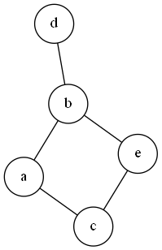

```python
from graphviz import Source
from IPython.display import Image

sample_graph = '''
graph {
    layout=neato
    node [shape=circle]
    a -- b; # These specify edges
    a -- c;
    b -- d;
    b -- e;
    c -- e;
}
'''
g = Source(sample_graph, filename='sample_graph', format='png')
g.render()
Image('sample_graph.png')
```

Here's an example of how to draw a directed graph using `graphviz`.

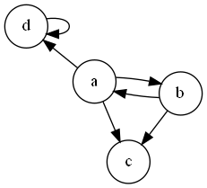

```python
from graphviz import Source
from IPython.display import Image

sample_directed_graph = '''
digraph {
    layout=neato;
    node [shape=circle];
    a->b;
    b->a;
    a->c;
    a->d;
    b->c;
    d->d;
  }
 '''
g = Source(sample_directed_graph, filename='sample_directed_graph', format='png')
g.render()
Image('sample_directed_graph.png')
```

### Exercise 12.1

Draw the following graphs. You may draw them by hand and attach a photo, draw them using ASCII art, or use a Python graph drawing tool, such as [networkx](https://networkx.org/documentation/stable/tutorial.html) or Graphviz.

1. V = {a,b,c,d,e}

   E = {{a,b}, {c,d}, {a,d}, {d,e}, {c,e}, {b,c}}
2. Adjacency list:

   $ \begin{array}{|c|l|} \hline a&b, c\\ b&a, c\\ c&a, b, d, e\\ d&c, e\\ e&c, d\\ \hline \end{array} $
3. Matrix representation

   $ \begin{matrix} & a&b&c&d&e&f&g\\ a&0&1&0&0&0&0&0\\ b&1&0&1&1&0&0&0\\ c&0&1&0&0&0&0&0\\ d&0&1&0&0&1&1&1\\ e&0&0&0&1&0&0&0\\ f&0&0&0&1&0&0&1\\ g&0&0&0&1&0&1&0 \end{matrix} $

#### Hint

Here's an example of how to draw a graph using `graphviz`.

```python
#@title Sample Code {display-mode: "form"}
from graphviz import Source

my_graph = '''
graph {
  layout=neato
  node [shape=circle]
  a -- b; # These specify edges
  a -- c;
  b -- d;
  b -- e;
  c -- e;
}'''
Source(my_graph)
```

### Exercise 12.2

Give the degree sequence for each of the following graphs.

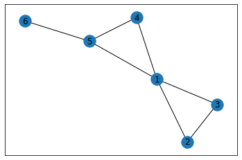

2.

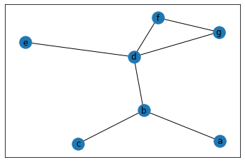

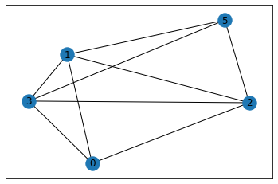

### Exercise 12.3

For the following graph, give:

1. The adjacency list representation
2. The matrix representation

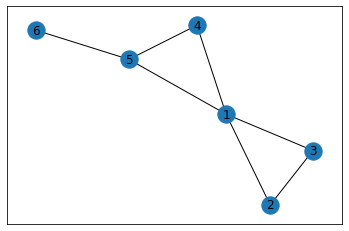

### Exercise 12.4

Each **edge** of a graph is colored with one of the four colors red, blue, orange, or green. How could you represent the edges in this graph using a variation of the adjacency matrix structure?

Create a matrix representation of this graph that includes color information for each edge.

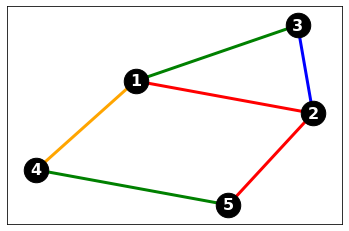

Question adapted from [Applied Discrete Structures](https://discretemath.org/) by Alan Doerr & Kenneth Levasseur which is licensed under a [Creative Commons Attribution-NonCommercial-ShareAlike 3.0 United States License](http://creativecommons.org/licenses/by-nc-sa/3.0/us/).

### Exercise 12.5

Use Python sets to represent the below graphs as a set of Vertices and Edges, then use the Python sets to determine whether each of them are subgraphs of graph $G$.

Hint: In Python, you cannot make a set containing sets. Instead, use a `tuple` or a `frozenset`. For example, to make a set of edges use something like this:

`edges = {('a', 'b'), ('c', 'd')}`

Graph $G$:

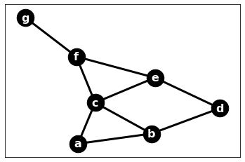

A.

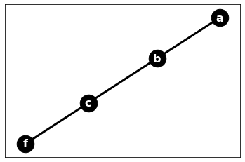

B.

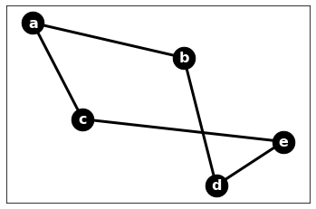

C.

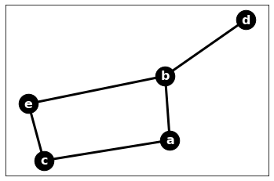

D.

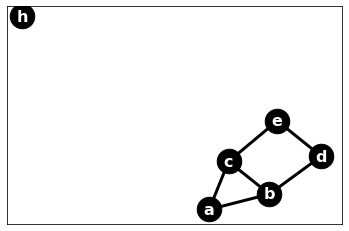

### Exercise 12.6

What is the maximum number of edges in an undirected graph with 11 vertices?

Hint: Think about this as a counting problem. How many vertices belong to each edge? How many combinations of edges are possible with 11 vertices?

### Exercise 12.7

Which of the graphs below are isomorphic? What is the correspondence between their vertices?

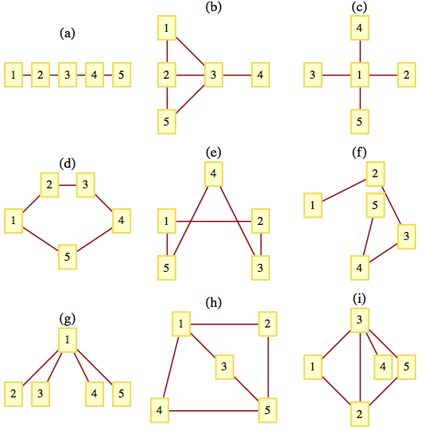

Question adapted from [Applied Discrete Structures](https://discretemath.org/) by Alan Doerr & Kenneth Levasseur which is licensed under a [Creative Commons Attribution-NonCommercial-ShareAlike 3.0 United States License](http://creativecommons.org/licenses/by-nc-sa/3.0/us/).

### Exercise 12.8

Suppose that you would like to mechanically describe the set of strings of 0's and 1's having no consecutive 1's. One way to visualize a string of this kind is with the graph below. Consider any path starting at vertex s. If the label on each graph is considered to be the output to a printer, then the output will have no consecutive 1's. For example, the path that is described by the vertex list (s,a,b,b,a,b,b,a,b) would result in an output of 10010010.

Draw a graph similar to the one shown here, but that represents the set of strings of 0's and 1's containing no more than two consecutive 1's in any part of the string.

```python
from graphviz import Source

graph1 = '''
digraph {
    layout=neato
    node [shape=circle]
    s->a [label=1];
    a->b [label=0];
    b->b [label=0];
    b->a [label=1];
    s->b [label=0]
}'''
Source(graph1)
```

[figure not shown]

### Exercise 12.9

Represent the following graph as an adjacency list using a Python dictionary.

Then, create a function to determine whether a given edge is in the graph.

Next, create a function to return all the neighbors of a given vertex.

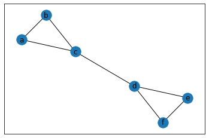

```python
adjacency_list = # your code here

def has_edge(edge, adjacency_list):
    # your code here
    pass

def find_neighbors(vertex, adjacency_list):
    #your code here
    pass


edge1 = ['a', 'b'] # this edge is in the graph
edge2 = ['d', 'f'] # this edge is in the graph
edge3 = ['c', 'f'] # this edge is not in the graph

print(has_edge(edge1, adjacency_list)) # should be True
print(has_edge(edge2, adjacency_list)) # should be True
print(has_edge(edge3, adjacency_list)) # should be False

print(find_neighbors('a', adjacency_list)) # should print ['b', 'c']
print(find_neighbors('d', adjacency_list)) # should print ['c', 'e', 'f']
```

## Sample Solutions

**Note**: Sample solutions are provided in order to help you **learn**. The purpose of these exercises is not to simply turn in the answers, but to take the time and effort to learn and understand the material. You are encouraged to work the problems first, then when you are satisfied that you have the correct answer, look at the sample solution and compare it with yours.

### Sample Solution 12.1

```python
from graphviz import Source

graph1 = '''
graph {
    layout=neato
    node [shape=circle]
    a--b;
    c--d;
    a--d;
    d--e;
    c--e;
    b--c;
}'''
Source(graph1)
```

```python
graph2 = '''
graph {
    layout=neato
    node [shape=circle]
    a--b;
    a--c;
    b--c;
    c--d;
    c--e;
    d--e;
}
'''
Source(graph2)
```

```python
graph3 = '''
graph {
    layout=neato
    node [shape=circle]
    a--b;
    b--c;
    b--d;
    d--e;
    d--f;
    d--g;
    f--g;

}
'''
Source(graph3)
```

### Sample Solution 12.2

1. 4 3 2 2 2 1
2. 4 3 2 2 1 1 1
3. 4 4 4 3 3

### Sample Solution 12.3

1. 1: 2, 3, 4, 5\ 2: 1, 3\ 3: 1, 2\ 4: 1, 5\ 5: 1, 4, 6\ 6: 5
2. 0 1 1 1 1 0 \ 1 0 1 0 0 0 \ 1 1 0 0 0 0 \ 1 0 0 0 1 0 \ 1 0 0 1 0 1 \ 0 0 0 0 1 0

### Sample Solution 12.4

$\begin{matrix} 0 & r & g & o & 0 \\ r & 0 & b & 0 & r \\ g & b & 0 & 0 & 0 \\ o & 0 & 0 & 0 & g \\ 0 & r & 0 & g & 0 \end{matrix}$

### Sample Solution 12.5

```python
G_v = {'a', 'b', 'c', 'd', 'e', 'f', 'g'}
G_e = {('a', 'b'), ('a', 'c'), ('b', 'c'), ('b', 'd'), ('d', 'e'), ('c', 'e'), ('c', 'f'), ('f', 'g')}

# Part A
A_v = {'a', 'b', 'c', 'f'}
A_e = {('a', 'b'), ('b', 'c'), ('c', 'f')}
print(f'A. {A_e.issubset(G_e) and A_v.issubset(G_v)}')


# Other code similar to part A

# B. True
# C. False
# D. False
```

### Sample Solution 12.6

Each edge is a pair of two vertices. So we need to find the number of combinations of two vertices when there are 11 vertices to choose from. The maximum number of edges in a graph with 11 vertices is ${11 \choose 2} = 55$

### Sample Solution 12.8

```python
from graphviz import Source

graph1 = '''
digraph {
    layout=neato
    node [shape=circle]
    s->a [label=1];
    s->c [label=0];
    a->b [label=1];
    a->c [label=0];
    b->c [label=0];
    c->c [label=0];
    c->a [label=1];
}'''
Source(graph1)
```

### Sample Solution 12.9

```python
adjacency_list = {
    'a': ['b', 'c'],
    'b': ['a', 'c'],
    'c': ['a', 'b', 'd'],
    'd': ['c', 'e', 'f'],
    'e': ['d', 'f'],
    'f': ['d', 'e']
}

def has_edge(edge, adjacency_list):
    return edge[1] in adjacency_list[edge[0]]


def find_neighbors(vertex, adjacency_list):
    return adjacency_list[vertex]


edge1 = ['a', 'b'] # this edge is in the graph
edge2 = ['d', 'f'] # this edge is in the graph
edge3 = ['c', 'f'] # this edge is not in the graph

print(has_edge(edge1, adjacency_list)) # should be True
print(has_edge(edge2, adjacency_list)) # should be True
print(has_edge(edge3, adjacency_list)) # should be False

print(find_neighbors('a', adjacency_list)) # should print ['b', 'c']
print(find_neighbors('d', adjacency_list)) # should print ['c', 'e', 'f']
```